# CITS4009-Individual Project

Henry TRAN - 23035141

2024-10-12

```r
# Install all the required packages for data processing, data transformation and data visualization
library(ggplot2)
library(shiny)
library(gridExtra)
library(reshape2)
library(readxl)
library(dplyr)
```

# Introduction

In the world every year, there are different numbers of death recorded because of various reasons. Depends on the countries and regions, the numbers of death in each death reasons could be unique. For example, there are higher numbers of death recorded in high-income countries due to smoking, compared to low-income countries with higher numbers of death because of starving. In this report, the Country and Death causes dataset from World Health Organisation recorded from 1990 to 2019 is used for data exploration and modelling to investigate the death causes in different countries and how they will be utilised for making binary classifiers, clustering.

We need to load the data for this task

```r
# Read the data
path<-url("https://lms.uwa.edu.au/bbcswebdav/pid-3998436-dt-content-rid-47695412_1/courses/CITS4009_SEM-2_2024/Countries%20and%20death%20causes.csv")
```

# Data Exploratory

```r
data<-read.csv(path, header=TRUE)
head(data)
```

```
##        Entity Code Year Outdoor.air.pollution High.systolic.blood.pressure
## 1 Afghanistan  AFG 1990                  3169                        25633
## 2 Afghanistan  AFG 1991                  3222                        25872
## 3 Afghanistan  AFG 1992                  3395                        26309
## 4 Afghanistan  AFG 1993                  3623                        26961
## 5 Afghanistan  AFG 1994                  3788                        27658
## 6 Afghanistan  AFG 1995                  3869                        28090
##   Diet.high.in.sodium Diet.low.in.whole.grains Alochol.use Diet.low.in.fruits
## 1                1045                     7077         356               3185
## 2                1055                     7149         364               3248
## 3                1075                     7297         376               3351
## 4                1103                     7499         389               3480
## 5                1134                     7698         399               3610
## 6                1154                     7807         406               3703
##   Unsafe.water.source Secondhand.smoke Low.birth.weight Child.wasting
```

[output cut: 48 more lines]

```r
nrow(data)
```

```
## [1] 6840
```

```r
ncol(data)
```

```
## [1] 31
```

The data has 31 columns and 6840 rows. For the column names, they can be seen that the column names have dot-separated between each word.

```r
str(data)
```

```
## 'data.frame':    6840 obs. of  31 variables:
##  $ Entity                                  : chr  "Afghanistan" "Afghanistan" "Afghanistan" "Afghanistan" ...
##  $ Code                                    : chr  "AFG" "AFG" "AFG" "AFG" ...
##  $ Year                                    : int  1990 1991 1992 1993 1994 1995 1996 1997 1998 1999 ...
##  $ Outdoor.air.pollution                   : int  3169 3222 3395 3623 3788 3869 3943 4024 4040 4042 ...
##  $ High.systolic.blood.pressure            : int  25633 25872 26309 26961 27658 28090 28587 29021 29349 29712 ...
##  $ Diet.high.in.sodium                     : int  1045 1055 1075 1103 1134 1154 1178 1202 1222 1242 ...
##  $ Diet.low.in.whole.grains                : int  7077 7149 7297 7499 7698 7807 7943 8075 8173 8265 ...
##  $ Alochol.use                             : int  356 364 376 389 399 406 413 420 425 426 ...
##  $ Diet.low.in.fruits                      : int  3185 3248 3351 3480 3610 3703 3819 3938 4038 4127 ...
##  $ Unsafe.water.source                     : int  3702 4309 5356 7152 7192 8378 8487 9348 9788 9931 ...
##  $ Secondhand.smoke                        : int  4794 4921 5279 5734 6050 6167 6298 6425 6402 6323 ...
##  $ Low.birth.weight                        : int  16135 17924 21200 23795 24866 25534 25997 26246 25805 25080 ...
##  $ Child.wasting                           : int  19546 20334 22895 27002 29205 30943 31628 32736 32760 32271 ...
##  $ Unsafe.sex                              : int  351 361 378 395 410 422 435 448 458 469 ...
```

[output cut: 17 more lines]

```r
summary(data)
```

```
##     Entity              Code                Year      Outdoor.air.pollution
##  Length:6840        Length:6840        Min.   :1990   Min.   :      0
##  Class :character   Class :character   1st Qu.:1997   1st Qu.:    434
##  Mode  :character   Mode  :character   Median :2004   Median :   2101
##                                        Mean   :2004   Mean   :  84582
##                                        3rd Qu.:2012   3rd Qu.:  11810
##                                        Max.   :2019   Max.   :4506193
##  High.systolic.blood.pressure Diet.high.in.sodium Diet.low.in.whole.grains
##  Min.   :       2             Min.   :      0.0   Min.   :      0.0
##  1st Qu.:    1828             1st Qu.:    137.0   1st Qu.:    273.8
##  Median :    8770             Median :    969.5   Median :   1444.0
##  Mean   :  224225             Mean   :  40497.2   Mean   :  38691.3
##  3rd Qu.:   40356             3rd Qu.:   5169.8   3rd Qu.:   6773.2
##  Max.   :10845595             Max.   :1885356.0   Max.   :1844836.0
##   Alochol.use        Diet.low.in.fruits  Unsafe.water.source Secondhand.smoke
##  Min.   :      0.0   Min.   :      0.0   Min.   :      0.0   Min.   :      1
##  1st Qu.:    263.8   1st Qu.:    144.0   1st Qu.:      7.0   1st Qu.:    209
##  Median :   1780.5   Median :    834.5   Median :    182.5   Median :    994
##  Mean   :  54848.6   Mean   :  23957.8   Mean   :  44086.4   Mean   :  30364
##  3rd Qu.:   8368.0   3rd Qu.:   3104.8   3rd Qu.:   5599.2   3rd Qu.:   4348
##  Max.   :2441973.0   Max.   :1046015.0   Max.   :2450944.0   Max.   :1304318
##  Low.birth.weight  Child.wasting       Unsafe.sex
##  Min.   :      0   Min.   :      0   Min.   :      0
##  1st Qu.:    123   1st Qu.:     26   1st Qu.:     97
##  Median :   1057   Median :    504   Median :    619
##  Mean   :  59126   Mean   :  49924   Mean   :  27646
##  3rd Qu.:  10903   3rd Qu.:   9765   3rd Qu.:   4492
##  Max.   :3033425   Max.   :3430422   Max.   :1664813
##  Diet.low.in.nuts.and.seeds Household.air.pollution.from.solid.fuels
##  Min.   :     0             Min.   :      0
##  1st Qu.:    27             1st Qu.:     32
##  Median :   252             Median :    821
##  Mean   : 12996             Mean   :  83641
##  3rd Qu.:  1998             3rd Qu.:  10870
##  Max.   :575139             Max.   :4358214
##  Diet.low.in.Vegetables Low.physical.activity    Smoking
##  Min.   :     0.0       Min.   :     0.0      Min.   :      1
##  1st Qu.:   109.0       1st Qu.:    92.0      1st Qu.:    894
##  Median :   590.5       Median :   521.5      Median :   4987
##  Mean   : 11982.5       Mean   : 16489.1      Mean   : 181958
```

[output cut: 15 more lines]

```
##  Max.   :1842275   Max.   :1200349                   Max.   :494492
##  Low.bone.mineral.density Vitamin.A.deficiency Child.stunting
##  Min.   :     0           Min.   :     0.0     Min.   :     0.0
##  1st Qu.:    43           1st Qu.:     0.0     1st Qu.:     1.0
##  Median :   277           Median :     2.0     Median :    41.5
##  Mean   :  8182           Mean   :  2471.6     Mean   : 11164.3
##  3rd Qu.:  1232           3rd Qu.:   230.2     3rd Qu.:  1563.2
##  Max.   :437884           Max.   :207555.0     Max.   :833449.0
##  Discontinued.breastfeeding Non.exclusive.breastfeeding Iron.deficiency
##  Min.   :    0.00           Min.   :     0.0            Min.   :    0
##  1st Qu.:    0.00           1st Qu.:     3.0            1st Qu.:    1
##  Median :    4.00           Median :    60.5            Median :   12
##  Mean   :  431.46           Mean   :  7171.9            Mean   : 1421
##  3rd Qu.:   71.25           3rd Qu.:  1315.5            3rd Qu.:  238
##  Max.   :33106.00           Max.   :505470.0            Max.   :73461
```

When exploring the data type of the dataset, Entity and Code are in character, while other columns are in numerical. As Entity and Code are unique for each country, then it should be changed to factor. Among the numerical data, Year should be changed to factor as well, since Year will not be used for any calculation.

```r
#converting Entity, Code and Year to factor
data$Entity<-as.factor(data$Entity)
data$Code<-as.factor(data$Code)
data$Year<-as.factor(data$Year)

summary(data)
```

```
##                   Entity          Code           Year
##  Afghanistan         :  30          : 690   1990   : 228
##  African Region (WHO):  30   AFG    :  30   1991   : 228
##  Albania             :  30   AGO    :  30   1992   : 228
##  Algeria             :  30   ALB    :  30   1993   : 228
##  American Samoa      :  30   AND    :  30   1994   : 228
##  Andorra             :  30   ARE    :  30   1995   : 228
##  (Other)             :6660   (Other):6000   (Other):5472
##  Outdoor.air.pollution High.systolic.blood.pressure Diet.high.in.sodium
##  Min.   :      0       Min.   :       2             Min.   :      0.0
##  1st Qu.:    434       1st Qu.:    1828             1st Qu.:    137.0
##  Median :   2101       Median :    8770             Median :    969.5
##  Mean   :  84582       Mean   :  224225             Mean   :  40497.2
##  3rd Qu.:  11810       3rd Qu.:   40356             3rd Qu.:   5169.8
##  Max.   :4506193       Max.   :10845595             Max.   :1885356.0
##
##  Diet.low.in.whole.grains  Alochol.use        Diet.low.in.fruits
##  Min.   :      0.0        Min.   :      0.0   Min.   :      0.0
##  1st Qu.:    273.8        1st Qu.:    263.8   1st Qu.:    144.0
##  Median :   1444.0        Median :   1780.5   Median :    834.5
##  Mean   :  38691.3        Mean   :  54848.6   Mean   :  23957.8
##  3rd Qu.:   6773.2        3rd Qu.:   8368.0   3rd Qu.:   3104.8
##  Max.   :1844836.0        Max.   :2441973.0   Max.   :1046015.0
##
##  Unsafe.water.source Secondhand.smoke  Low.birth.weight  Child.wasting
##  Min.   :      0.0   Min.   :      1   Min.   :      0   Min.   :      0
##  1st Qu.:      7.0   1st Qu.:    209   1st Qu.:    123   1st Qu.:     26
##  Median :    182.5   Median :    994   Median :   1057   Median :    504
##  Mean   :  44086.4   Mean   :  30364   Mean   :  59126   Mean   :  49924
##  3rd Qu.:   5599.2   3rd Qu.:   4348   3rd Qu.:  10903   3rd Qu.:   9765
##  Max.   :2450944.0   Max.   :1304318   Max.   :3033425   Max.   :3430422
##
##    Unsafe.sex      Diet.low.in.nuts.and.seeds
##  Min.   :      0   Min.   :     0
##  1st Qu.:     97   1st Qu.:    27
##  Median :    619   Median :   252
##  Mean   :  27646   Mean   : 12996
##  3rd Qu.:   4492   3rd Qu.:  1998
##  Max.   :1664813   Max.   :575139
##
```

[output cut: 33 more lines]

```
##  Min.   :     0.0     Min.   :     0.0   Min.   :    0.00
##  1st Qu.:     0.0     1st Qu.:     1.0   1st Qu.:    0.00
##  Median :     2.0     Median :    41.5   Median :    4.00
##  Mean   :  2471.6     Mean   : 11164.3   Mean   :  431.46
##  3rd Qu.:   230.2     3rd Qu.:  1563.2   3rd Qu.:   71.25
##  Max.   :207555.0     Max.   :833449.0   Max.   :33106.00
##
##  Non.exclusive.breastfeeding Iron.deficiency
##  Min.   :     0.0            Min.   :    0
##  1st Qu.:     3.0            1st Qu.:    1
##  Median :    60.5            Median :   12
##  Mean   :  7171.9            Mean   : 1421
##  3rd Qu.:  1315.5            3rd Qu.:  238
##  Max.   :505470.0            Max.   :73461
##
```

```r
str(data)
```

```
## 'data.frame':    6840 obs. of  31 variables:
##  $ Entity                                  : Factor w/ 228 levels "Afghanistan",..: 1 1 1 1 1 1 1 1 1 1 ...
##  $ Code                                    : Factor w/ 206 levels "","AFG","AGO",..: 2 2 2 2 2 2 2 2 2 2 ...
##  $ Year                                    : Factor w/ 30 levels "1990","1991",..: 1 2 3 4 5 6 7 8 9 10 ...
##  $ Outdoor.air.pollution                   : int  3169 3222 3395 3623 3788 3869 3943 4024 4040 4042 ...
##  $ High.systolic.blood.pressure            : int  25633 25872 26309 26961 27658 28090 28587 29021 29349 29712 ...
##  $ Diet.high.in.sodium                     : int  1045 1055 1075 1103 1134 1154 1178 1202 1222 1242 ...
##  $ Diet.low.in.whole.grains                : int  7077 7149 7297 7499 7698 7807 7943 8075 8173 8265 ...
##  $ Alochol.use                             : int  356 364 376 389 399 406 413 420 425 426 ...
##  $ Diet.low.in.fruits                      : int  3185 3248 3351 3480 3610 3703 3819 3938 4038 4127 ...
##  $ Unsafe.water.source                     : int  3702 4309 5356 7152 7192 8378 8487 9348 9788 9931 ...
##  $ Secondhand.smoke                        : int  4794 4921 5279 5734 6050 6167 6298 6425 6402 6323 ...
##  $ Low.birth.weight                        : int  16135 17924 21200 23795 24866 25534 25997 26246 25805 25080 ...
##  $ Child.wasting                           : int  19546 20334 22895 27002 29205 30943 31628 32736 32760 32271 ...
##  $ Unsafe.sex                              : int  351 361 378 395 410 422 435 448 458 469 ...
```

[output cut: 17 more lines]

It could be seen that the each Entity and Code appeared 30 times in the dataset, which is matched with the number of years we have from 1990 to 2019. Among the numerical data, it could be seen that the gap between values are really large

```r
unique(data$Entity)
```

```
##   [1] Afghanistan                        African Region (WHO)
##   [3] Albania                            Algeria
##   [5] American Samoa                     Andorra
##   [7] Angola                             Antigua and Barbuda
##   [9] Argentina                          Armenia
##  [11] Australia                          Austria
##  [13] Azerbaijan                         Bahamas
##  [15] Bahrain                            Bangladesh
##  [17] Barbados                           Belarus
##  [19] Belgium                            Belize
##  [21] Benin                              Bermuda
##  [23] Bhutan                             Bolivia
##  [25] Bosnia and Herzegovina             Botswana
##  [27] Brazil                             Brunei
##  [29] Bulgaria                           Burkina Faso
```

[output cut: 100 more lines]

There are 228 unique entities but there are only 206 codes in this dataset. The reason is because there are some countries and regions do not have unique codes.

There are also no missing data

```r
#checking missing value
total_missing_value = sum(is.na(data))
total_missing_value
```

```
## [1] 0
```

As I mentioned above, the gap between numbers of recorded death are extremely large within 28 death causes. The reason is because the dataset did not only record deaths of countries, but it also recorded the total deaths in groups, regions and in the world. Therefore, if we do the data analysis on the whole dataset, it will create skewness problem. The solution for this would be we can seperated data into different groups: countries and regions. When we do the boxplot of one death cause, it will be really skewed and we could not analyse anything from it

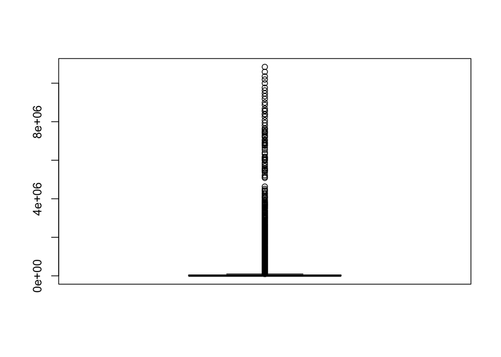

```r
#taking High.systolic.blood.pressure to illustrate the skewness
boxplot(data$High.systolic.blood.pressure)
```

## Data Transformation

Firstly, the data will be divided into 2 groups: countries and regions

There are 228 countries and regions in this data. There are few information we can know if the Entity is a region or world, including the Entity: - Ends with (WB) or (WHO) - Start with “World” - G20 And anything other than this will be considered to be countries. Here is how we will divide the data into groups

```r
#create a mask to filter out the regions and the regions
region_mask <- grepl("(WB)|(WHO)|^World|^G20|^OECD", data$Entity)

regions<-data[region_mask,]
countries<-data[!region_mask,]
```

```r
head(countries)
```

```
##        Entity Code Year Outdoor.air.pollution High.systolic.blood.pressure
## 1 Afghanistan  AFG 1990                  3169                        25633
## 2 Afghanistan  AFG 1991                  3222                        25872
## 3 Afghanistan  AFG 1992                  3395                        26309
## 4 Afghanistan  AFG 1993                  3623                        26961
## 5 Afghanistan  AFG 1994                  3788                        27658
## 6 Afghanistan  AFG 1995                  3869                        28090
##   Diet.high.in.sodium Diet.low.in.whole.grains Alochol.use Diet.low.in.fruits
## 1                1045                     7077         356               3185
## 2                1055                     7149         364               3248
## 3                1075                     7297         376               3351
## 4                1103                     7499         389               3480
## 5                1134                     7698         399               3610
## 6                1154                     7807         406               3703
##   Unsafe.water.source Secondhand.smoke Low.birth.weight Child.wasting
```

[output cut: 48 more lines]

```r
dim(countries)
```

```
## [1] 6240   31
```

With countries dataset, there are 6240 rows and 31 columns, including 28 death causes

```r
head(regions)
```

```
##                  Entity Code Year Outdoor.air.pollution
## 31 African Region (WHO)      1990                 93970
## 32 African Region (WHO)      1991                 96436
## 33 African Region (WHO)      1992                 99700
## 34 African Region (WHO)      1993                101913
## 35 African Region (WHO)      1994                105532
## 36 African Region (WHO)      1995                109104
##    High.systolic.blood.pressure Diet.high.in.sodium Diet.low.in.whole.grains
## 31                       356866               46758                    45763
## 32                       365975               47439                    46897
## 33                       377948               48304                    48317
## 34                       386490               48805                    49393
## 35                       398794               49520                    50736
## 36                       410153               50425                    51970
##    Alochol.use Diet.low.in.fruits Unsafe.water.source Secondhand.smoke
```

[output cut: 48 more lines]

```r
dim(regions)
```

```
## [1] 600  31
```

While with regions dataset, there are 600 rows and 31 columns, also including 28 death causes

As the dataset is divided into 2 groups, then we will use both of them for the next steps of classification modelling and clustering.

#Model: Binary classification of High-income countries based on death causes ## Data Transformation For the classification model, the model will classify the high-income countries based on the death causes. The reason to build this model is because the numbers of death in high-income countries could because of different causes compared to countries from other income-groups. For each death causes of each country, the total numbers of death will be calculated and then be used for classification and clustering.

According to World Bank, there are 86 countries in the high-income group. Therefore, we will have a column to label them, the country in high-income group will be 1 and 0 for countries from other income groups.

There is a data file of countries in regions from World Bank. This file will be merge with the current data that we are processing

```r
#here is my file path, please change to your filepath to where you downloaded the file to run the code below
path<-"/Users/henrytran/Documents/UWA_Master-Data-Science/CITS4009/Project/"
```

```r
#create a path that can access and extractn the data
country_groups_file<- paste0(path, "World Bank Country Groups.xlsx")
country_groups_dataset<-read_excel(country_groups_file, sheet = "List of economies")
head(country_groups_dataset)
```

```
## # A tibble: 6 × 5
##   Economy        Code  Region                  `Income group` `Lending category`
##   <chr>          <chr> <chr>                   <chr>          <chr>
## 1 Afghanistan    AFG   South Asia              Low income     IDA
## 2 Albania        ALB   Europe & Central Asia   Upper middle … IBRD
## 3 Algeria        DZA   Middle East & North Af… Upper middle … IBRD
## 4 American Samoa ASM   East Asia & Pacific     High income    <NA>
## 5 Andorra        AND   Europe & Central Asia   High income    <NA>
## 6 Angola         AGO   Sub-Saharan Africa      Lower middle … IBRD
```

The data that we need will include the the Economy, Code and Income group. Therefore, we will keep only 3 columns for this dataset

```r
country_groups_dataset<-country_groups_dataset[,c(1,2,4)] #We need the first 3 columns - Economy, Code, Region
head(country_groups_dataset)
```

```
## # A tibble: 6 × 3
##   Economy        Code  `Income group`
##   <chr>          <chr> <chr>
## 1 Afghanistan    AFG   Low income
## 2 Albania        ALB   Upper middle income
## 3 Algeria        DZA   Upper middle income
## 4 American Samoa ASM   High income
## 5 Andorra        AND   High income
## 6 Angola         AGO   Lower middle income
```

Now, we will merge countries dataset with country groups dataset using Code as key, and we keep all the data on the countries dataset

```r
countries_merged<-merge(countries, country_groups_dataset, by.x="Code", by.y="Code", all.x=TRUE)
head(countries_merged)
```

```
##   Code           Entity Year Outdoor.air.pollution High.systolic.blood.pressure
## 1      Northern Ireland 1990                   828                         4073
## 2      Northern Ireland 1991                   800                         4031
## 3      Northern Ireland 1992                   770                         3982
## 4      Northern Ireland 1993                   772                         4090
## 5      Northern Ireland 1994                   740                         4007
## 6      Northern Ireland 1995                   730                         4033
##   Diet.high.in.sodium Diet.low.in.whole.grains Alochol.use Diet.low.in.fruits
## 1                 313                      907         316                413
## 2                 300                      882         324                404
## 3                 289                      858         329                393
## 4                 286                      869         351                398
## 5                 272                      838         362                386
## 6                 267                      833         376                384
##   Unsafe.water.source Secondhand.smoke Low.birth.weight Child.wasting
```

[output cut: 55 more lines]

As I look through both the dataset, there are 4 countries do not have Code, including Northen Ireland, Wales, Scotland, and England. They are all in United Kingdom (UK). Now we will double check to see if the total death of UK is the same to the total death of 4 countries

```r
#calculate the total death of UK over 30 years for all death causes
total_uk_death <- colSums(countries_merged[countries_merged$Entity=="United Kingdom", 4:31], na.rm = TRUE)
total_uk_death
```

```
##                    Outdoor.air.pollution
##                                   777587
##             High.systolic.blood.pressure
##                                  3635595
##                      Diet.high.in.sodium
##                                   228934
##                 Diet.low.in.whole.grains
##                                   773281
##                              Alochol.use
##                                   587109
##                       Diet.low.in.fruits
##                                   363439
##                      Unsafe.water.source
##                                     1171
##                         Secondhand.smoke
##                                   319841
##                         Low.birth.weight
##                                    55390
##                            Child.wasting
##                                     5228
##                               Unsafe.sex
##                                    66968
##               Diet.low.in.nuts.and.seeds
##                                   438036
## Household.air.pollution.from.solid.fuels
##                                      991
##                   Diet.low.in.Vegetables
##                                   230929
##                    Low.physical.activity
##                                   490896
##                                  Smoking
##                                  4220418
##              High.fasting.plasma.glucose
##                                  2052310
##                            Air.pollution
##                                   776815
##                     High.body.mass.index
##                                  1672380
##                        Unsafe.sanitation
##                                      261
##        No.access.to.handwashing.facility
##                                    13334
##                                 Drug.use
##                                   108793
##                 Low.bone.mineral.density
##                                   113395
##                     Vitamin.A.deficiency
##                                        0
##                           Child.stunting
##                                      108
##               Discontinued.breastfeeding
##                                       30
##              Non.exclusive.breastfeeding
##                                      571
##                          Iron.deficiency
##                                      171
```

```r
#calculate the total death of England, Northern Ireland, Wales, Scotland over 30 years for all death causes
four_countries_death <- subset(countries_merged, Entity %in% c("England", "Northern Ireland", "Wales", "Scotland"))
total_four_countries_death <- colSums(four_countries_death[, 4:31], na.rm = TRUE)
total_four_countries_death
```

```
##                    Outdoor.air.pollution
##                                   777587
##             High.systolic.blood.pressure
##                                  3635594
##                      Diet.high.in.sodium
##                                   228935
##                 Diet.low.in.whole.grains
##                                   773283
##                              Alochol.use
##                                   587106
##                       Diet.low.in.fruits
##                                   363442
##                      Unsafe.water.source
##                                     1168
##                         Secondhand.smoke
##                                   319843
##                         Low.birth.weight
##                                    55389
##                            Child.wasting
##                                     5233
##                               Unsafe.sex
##                                    66966
##               Diet.low.in.nuts.and.seeds
##                                   438037
## Household.air.pollution.from.solid.fuels
##                                      993
##                   Diet.low.in.Vegetables
##                                   230931
##                    Low.physical.activity
##                                   490897
##                                  Smoking
##                                  4220422
##              High.fasting.plasma.glucose
##                                  2052311
##                            Air.pollution
##                                   776821
##                     High.body.mass.index
##                                  1672375
##                        Unsafe.sanitation
##                                      250
##        No.access.to.handwashing.facility
##                                    13333
##                                 Drug.use
##                                   108797
##                 Low.bone.mineral.density
##                                   113393
##                     Vitamin.A.deficiency
##                                        0
##                           Child.stunting
##                                       92
##               Discontinued.breastfeeding
##                                       30
##              Non.exclusive.breastfeeding
##                                      574
##                          Iron.deficiency
##                                      154
```

After calculating the total deaths of 4 countries over years, the numbers of death recorded for each reasons are almost the same to the total deaths of UK over years. Therefore, we will drop these 4 countries out of the countries merged dataset.

Now we will calculate the total death of each country for all death causes.

```r
#we keep the remaining countries
countries_merged<-merge(countries, country_groups_dataset, by.x="Code", by.y="Code")
countries_merged<-countries_merged[,-32]
head(countries_merged)
```

```
##   Code      Entity Year Outdoor.air.pollution High.systolic.blood.pressure
## 1  AFG Afghanistan 1998                  4040                        29349
## 2  AFG Afghanistan 1996                  3943                        28587
## 3  AFG Afghanistan 1997                  4024                        29021
## 4  AFG Afghanistan 1994                  3788                        27658
## 5  AFG Afghanistan 1995                  3869                        28090
## 6  AFG Afghanistan 1991                  3222                        25872
##   Diet.high.in.sodium Diet.low.in.whole.grains Alochol.use Diet.low.in.fruits
## 1                1222                     8173         425               4038
## 2                1178                     7943         413               3819
## 3                1202                     8075         420               3938
## 4                1134                     7698         399               3610
## 5                1154                     7807         406               3703
## 6                1055                     7149         364               3248
##   Unsafe.water.source Secondhand.smoke Low.birth.weight Child.wasting
```

[output cut: 55 more lines]

```r
#for the data, group the data into entity and income groups, then calculate the total death of each death causes of each country
names(countries_merged)[names(countries_merged) == "Income group"] <- "Income.group"
#using binning technique to calculate the sum of all death causes
total_countries_death <- countries_merged %>% group_by(Entity, Income.group) %>% summarise(across(c("Outdoor.air.pollution": "Iron.deficiency"), sum))
head(total_countries_death)
```

```
## # A tibble: 6 × 30
## # Groups:   Entity [6]
##   Entity         Income.group       Outdoor.air.pollution High.systolic.blood.…¹
##   <fct>          <chr>                              <int>                  <int>
## 1 Afghanistan    Low income                        155341                 906211
## 2 Albania        Upper middle inco…                 35720                 163948
## 3 Algeria        Upper middle inco…                491987                1280486
## 4 American Samoa High income                          182                   1916
## 5 Andorra        High income                          418                   2086
## 6 Angola         Lower middle inco…                 85596                 352606
## # ℹ abbreviated name: ¹High.systolic.blood.pressure
## # ℹ 26 more variables: Diet.high.in.sodium <int>,
## #   Diet.low.in.whole.grains <int>, Alochol.use <int>,
## #   Diet.low.in.fruits <int>, Unsafe.water.source <int>,
## #   Secondhand.smoke <int>, Low.birth.weight <int>, Child.wasting <int>,
## #   Unsafe.sex <int>, Diet.low.in.nuts.and.seeds <int>,
## #   Household.air.pollution.from.solid.fuels <int>, …
```

After aggregating the model, now we will create a label for each country, in a column called ‘Label’. As mentioned previously, the countries with high income will be 1 and 0 for countries in other income groups. Label will be the last column in this dataset

```r
label_total_countries_death<-total_countries_death
label_total_countries_death$Label<-ifelse(total_countries_death$Income.group == "High income", 1, 0)
label_total_countries_death$Label<-as.factor(label_total_countries_death$Label)
head(label_total_countries_death)
```

```
## # A tibble: 6 × 31
## # Groups:   Entity [6]
##   Entity         Income.group       Outdoor.air.pollution High.systolic.blood.…¹
##   <fct>          <chr>                              <int>                  <int>
## 1 Afghanistan    Low income                        155341                 906211
## 2 Albania        Upper middle inco…                 35720                 163948
## 3 Algeria        Upper middle inco…                491987                1280486
## 4 American Samoa High income                          182                   1916
## 5 Andorra        High income                          418                   2086
## 6 Angola         Lower middle inco…                 85596                 352606
## # ℹ abbreviated name: ¹High.systolic.blood.pressure
## # ℹ 27 more variables: Diet.high.in.sodium <int>,
## #   Diet.low.in.whole.grains <int>, Alochol.use <int>,
## #   Diet.low.in.fruits <int>, Unsafe.water.source <int>,
## #   Secondhand.smoke <int>, Low.birth.weight <int>, Child.wasting <int>,
## #   Unsafe.sex <int>, Diet.low.in.nuts.and.seeds <int>,
## #   Household.air.pollution.from.solid.fuels <int>, …
```

```r
#check if there is any NA values in the data
sum(is.na(label_total_countries_death))
```

```
## [1] 2
```

```r
label_total_countries_death[!complete.cases(label_total_countries_death),]
```

```
## # A tibble: 1 × 31
## # Groups:   Entity [1]
##   Entity    Income.group Outdoor.air.pollution High.systolic.blood.pressure
##   <fct>     <chr>                        <int>                        <int>
## 1 Venezuela <NA>                        235273                       803677
## # ℹ 27 more variables: Diet.high.in.sodium <int>,
## #   Diet.low.in.whole.grains <int>, Alochol.use <int>,
## #   Diet.low.in.fruits <int>, Unsafe.water.source <int>,
## #   Secondhand.smoke <int>, Low.birth.weight <int>, Child.wasting <int>,
## #   Unsafe.sex <int>, Diet.low.in.nuts.and.seeds <int>,
## #   Household.air.pollution.from.solid.fuels <int>,
## #   Diet.low.in.Vegetables <int>, Low.physical.activity <int>, Smoking <int>, …
```

There is one country - Venezuela, which was not classified with income group. This is because it was not specified in the country_groups_dataset from World Bank. As the dataset has 201 rows and only one row has NA values, it is a good decision for us to remove this country

```r
label_total_countries_death <- na.omit(label_total_countries_death)
```

```r
head(label_total_countries_death)
```

```
## # A tibble: 6 × 31
## # Groups:   Entity [6]
##   Entity         Income.group       Outdoor.air.pollution High.systolic.blood.…¹
##   <fct>          <chr>                              <int>                  <int>
## 1 Afghanistan    Low income                        155341                 906211
## 2 Albania        Upper middle inco…                 35720                 163948
## 3 Algeria        Upper middle inco…                491987                1280486
## 4 American Samoa High income                          182                   1916
## 5 Andorra        High income                          418                   2086
## 6 Angola         Lower middle inco…                 85596                 352606
## # ℹ abbreviated name: ¹High.systolic.blood.pressure
## # ℹ 27 more variables: Diet.high.in.sodium <int>,
## #   Diet.low.in.whole.grains <int>, Alochol.use <int>,
## #   Diet.low.in.fruits <int>, Unsafe.water.source <int>,
## #   Secondhand.smoke <int>, Low.birth.weight <int>, Child.wasting <int>,
## #   Unsafe.sex <int>, Diet.low.in.nuts.and.seeds <int>,
## #   Household.air.pollution.from.solid.fuels <int>, …
```

##Building model There are 2 models selected for high-income countries classification based on death causes. They are Decision Trees classifier, and Logistic Regression classifier

First of all, the data needs to be divided into 2 groups: training and testing.

```r
#we want to make the sampling be the same when we re-run it
set.seed(12345)
random_mask<-runif(nrow(label_total_countries_death))<0.8 #80% of data will be used for training, 20% of data will be used for testing
train_data<-label_total_countries_death[random_mask,]
test_data<-label_total_countries_death[!random_mask,]
```

We only take the Label columns with 28 death causes. There are 152 rows and 29 columns for training dataset, and 48 rows and 29 columns for testing dataset

```r
train_data<-train_data[,3:ncol(train_data)]
train_data
```

```
## # A tibble: 152 × 29
##    Outdoor.air.pollution High.systolic.blood.pressure Diet.high.in.sodium
##                    <int>                        <int>               <int>
##  1                155341                       906211               37252
##  2                491987                      1280486               42917
##  3                   418                         2086                 127
##  4                 85596                       352606               25181
##  5                   760                         3176                 284
##  6                360135                      1519926              198986
##  7                 89045                       218341               33963
##  8                117025                       573769               67968
##  9                180497                       568157               86707
## 10                  2305                        11937                 989
## # ℹ 142 more rows
## # ℹ 26 more variables: Diet.low.in.whole.grains <int>, Alochol.use <int>,
## #   Diet.low.in.fruits <int>, Unsafe.water.source <int>,
## #   Secondhand.smoke <int>, Low.birth.weight <int>, Child.wasting <int>,
## #   Unsafe.sex <int>, Diet.low.in.nuts.and.seeds <int>,
## #   Household.air.pollution.from.solid.fuels <int>,
## #   Diet.low.in.Vegetables <int>, Low.physical.activity <int>, Smoking <int>, …
```

```r
cat("Training dataset size is", dim(train_data))
```

```
## Training dataset size is 152 29
```

```r
test_data<-test_data[,3:ncol(test_data)]
test_data
```

```
## # A tibble: 48 × 29
##    Outdoor.air.pollution High.systolic.blood.pressure Diet.high.in.sodium
##                    <int>                        <int>               <int>
##  1                 35720                       163948               54436
##  2                   182                         1916                 136
##  3                 58460                       752258               32428
##  4                 41418                       149090               16622
##  5                 91105                       171231               30293
##  6                135013                       505618               70149
##  7              32828190                     54195998            20265539
##  8                142131                       358348               34259
##  9                   891                         4428                 413
## 10                 61363                       282820               25190
## # ℹ 38 more rows
## # ℹ 26 more variables: Diet.low.in.whole.grains <int>, Alochol.use <int>,
## #   Diet.low.in.fruits <int>, Unsafe.water.source <int>,
## #   Secondhand.smoke <int>, Low.birth.weight <int>, Child.wasting <int>,
## #   Unsafe.sex <int>, Diet.low.in.nuts.and.seeds <int>,
## #   Household.air.pollution.from.solid.fuels <int>,
## #   Diet.low.in.Vegetables <int>, Low.physical.activity <int>, Smoking <int>, …
```

```r
cat("Testing dataset size is", dim(test_data))
```

```
## Testing dataset size is 48 29
```

```r
#we separated the columns, including the responses and all features
responses<- colnames(label_total_countries_death) %in% c("Entity", "Income.group", "Label") # create a mask to filter out the responses and the features
all_features<-colnames(label_total_countries_death)[!responses]
all_features
```

```
##  [1] "Outdoor.air.pollution"
##  [2] "High.systolic.blood.pressure"
##  [3] "Diet.high.in.sodium"
##  [4] "Diet.low.in.whole.grains"
##  [5] "Alochol.use"
##  [6] "Diet.low.in.fruits"
##  [7] "Unsafe.water.source"
##  [8] "Secondhand.smoke"
##  [9] "Low.birth.weight"
## [10] "Child.wasting"
## [11] "Unsafe.sex"
## [12] "Diet.low.in.nuts.and.seeds"
## [13] "Household.air.pollution.from.solid.fuels"
## [14] "Diet.low.in.Vegetables"
## [15] "Low.physical.activity"
## [16] "Smoking"
## [17] "High.fasting.plasma.glucose"
## [18] "Air.pollution"
## [19] "High.body.mass.index"
## [20] "Unsafe.sanitation"
## [21] "No.access.to.handwashing.facility"
## [22] "Drug.use"
## [23] "Low.bone.mineral.density"
## [24] "Vitamin.A.deficiency"
## [25] "Child.stunting"
## [26] "Discontinued.breastfeeding"
## [27] "Non.exclusive.breastfeeding"
## [28] "Iron.deficiency"
```

### Best single variable and feature selections

#### Null model

In the training dataset, the probability of high-income countries in the dataset is around 0.322

```r
null_model_prob<-sum(train_data$Label==1)/nrow(train_data)
null_model_prob
```

```
## [1] 0.3223684
```

The null model probability is 0.3223684. This means that there are there are around 32% of the countries in the training dataset is high-income countries. This implies that when we do the performance comparision, any model that we build needs to perform better than this baseline value.

#### Best single-variable model

Another way to check if our models’ performance is to compare with best single-variate model.

We will loop through all of the numerical variable to create single variate models with the training data. Then the best single variate model will be selected

Now we will run through all single numerical variables and calculate the area under the curve values (AUCs)

```r
#this is the code followed from the lecture, with some modification
mkPredC<-function(outCol, varCol, appCol){ #training outcomes, training variable and prediction variable
  #we convert all the data to vector for easier calculation
  outCol <- as.vector(outCol)
  varCol <- as.vector(varCol)
  appCol <- as.vector(appCol)
  pOne<-sum(outCol==1)/length(outCol) #the probability of the outcome is 1 during training
  vTab<-table(outCol, varCol) #the table of training outcomes and training variable
  pOneWv<-(vTab[1,]+ 1.0e-3 *pOne)/(colSums(vTab)+ 1.0e-3) #how often the outcome is 1 with conditioned on levels of training variable
  pred<-pOneWv[appCol] #make prediction by looking up levels of appCol
  pred[is.na(pred)]<-pOne #add prediction for appCol that were unknown when training
  pred
}

mkPredN<- function(outCol, varCol, appCol){
  varCol <- as.numeric(varCol)  #we convert all the data to numerical to use for quantile function
  appCol <- as.numeric(appCol)  #we convert all the data to numerical to use for quantile function
  cuts<-unique(quantile(varCol, probs = seq(0,1,0.1), na.rm=T)) #we convert the numerical data to groups of categorical data
  varC<-cut(varCol, cuts) #we applied the cuts to the training variables
  appC<-cut(appCol, cuts) #we applied the cuts to the testing variable
  mkPredC(outCol, varC, appC)
}
```

```r
#this is the code followed from the lecture, with some modification
#import the ROCR library to create calcAUC function used for calculating single-variate model's AUCs
library('ROCR')
calcAUC <- function(predcol,outcol) {
  perf <- performance(prediction(predcol,outcol==1),'auc') #we are checking the performance of model predicting the value 1
  as.numeric(perf@y.values)
}
```

```r
#this is the code followed from the lecture, with some modification
for(var in all_features) {
  pi <- paste('pred', var, sep='')#create the predFeatures columns for each Features
  #we ensure the input is vector for Label, numeric for all features
  train_data[,pi] <- mkPredN(train_data[["Label"]], as.numeric(unlist(train_data[[var]])), as.numeric(unlist(train_data[[var]])))
  test_data[,pi] <- mkPredN(test_data[["Label"]], as.numeric(unlist(test_data[[var]])),as.numeric(unlist(test_data[[var]])))
  #calculate the AUCs values of single-variate model with training and testing dataset
  aucTrain <- calcAUC(train_data[,pi], train_data[,"Label"])
  aucTest <- calcAUC(test_data[,pi], test_data[,"Label"])
  print(sprintf("%s: trainAUC: %4.3f; testAUC: %4.3f",pi, aucTrain, aucTest))
}
```

```
## [1] "predOutdoor.air.pollution: trainAUC: 0.350; testAUC: 0.236"
## [1] "predHigh.systolic.blood.pressure: trainAUC: 0.359; testAUC: 0.284"
## [1] "predDiet.high.in.sodium: trainAUC: 0.330; testAUC: 0.279"
## [1] "predDiet.low.in.whole.grains: trainAUC: 0.321; testAUC: 0.279"
## [1] "predAlochol.use: trainAUC: 0.309; testAUC: 0.298"
## [1] "predDiet.low.in.fruits: trainAUC: 0.370; testAUC: 0.228"
## [1] "predUnsafe.water.source: trainAUC: 0.090; testAUC: 0.064"
## [1] "predSecondhand.smoke: trainAUC: 0.383; testAUC: 0.208"
## [1] "predLow.birth.weight: trainAUC: 0.159; testAUC: 0.099"
## [1] "predChild.wasting: trainAUC: 0.132; testAUC: 0.114"
## [1] "predUnsafe.sex: trainAUC: 0.241; testAUC: 0.195"
## [1] "predDiet.low.in.nuts.and.seeds: trainAUC: 0.342; testAUC: 0.180"
## [1] "predHousehold.air.pollution.from.solid.fuels: trainAUC: 0.122; testAUC: 0.059"
## [1] "predDiet.low.in.Vegetables: trainAUC: 0.340; testAUC: 0.313"
## [1] "predLow.physical.activity: trainAUC: 0.321; testAUC: 0.262"
## [1] "predSmoking: trainAUC: 0.313; testAUC: 0.318"
## [1] "predHigh.fasting.plasma.glucose: trainAUC: 0.311; testAUC: 0.194"
## [1] "predAir.pollution: trainAUC: 0.301; testAUC: 0.171"
## [1] "predHigh.body.mass.index: trainAUC: 0.314; testAUC: 0.228"
## [1] "predUnsafe.sanitation: trainAUC: 0.088; testAUC: 0.071"
## [1] "predNo.access.to.handwashing.facility: trainAUC: 0.137; testAUC: 0.145"
## [1] "predDrug.use: trainAUC: 0.348; testAUC: 0.276"
## [1] "predLow.bone.mineral.density: trainAUC: 0.326; testAUC: 0.267"
## [1] "predVitamin.A.deficiency: trainAUC: 0.059; testAUC: 0.065"
## [1] "predChild.stunting: trainAUC: 0.084; testAUC: 0.078"
## [1] "predDiscontinued.breastfeeding: trainAUC: 0.112; testAUC: 0.086"
## [1] "predNon.exclusive.breastfeeding: trainAUC: 0.087; testAUC: 0.055"
## [1] "predIron.deficiency: trainAUC: 0.109; testAUC: 0.100"
```

There are no variables having AUC higher than 0.5. This implies that there are no variables perform well in classifying the high-income countries with countries from other income groups. When calculating the area under the curve (AUC), it shows that the Secondhand.smoke variable has the highest AUC for training data, with value of 0.383. While looking at the AUC values for testing data, Smoking has the highest AUC with value of 0.318.

However, when try to predict whether a country is in non-high-income country group. The AUCs are so much higher on both training and testing data.

```r
#for this code, we are checking the performance of model predicting the value 0
calcAUC <- function(predcol,outcol) {
  perf <- performance(prediction(predcol,outcol==0),'auc')
  as.numeric(perf@y.values)
}
```

```r
#this is the code followed from the lecture, with some modification
for(var in all_features) {
  pi <- paste('pred', var, sep='') #create the predFeatures columns for each Features
  #we ensure the input is vector for Label, numeric for all features
  train_data[,pi] <- mkPredN(train_data[["Label"]], as.numeric(unlist(train_data[[var]])), as.numeric(unlist(train_data[[var]])))
  test_data[,pi] <- mkPredN(test_data[["Label"]], as.numeric(unlist(test_data[[var]])),as.numeric(unlist(test_data[[var]])))
  #calculate the AUCs values of single-variate model with training and testing dataset
  aucTrain <- calcAUC(train_data[,pi], train_data[,"Label"])
  aucTest <- calcAUC(test_data[,pi], test_data[,"Label"])
  print(sprintf("%s: trainAUC: %4.3f; testAUC: %4.3f",pi, aucTrain, aucTest))
}
```

```
## [1] "predOutdoor.air.pollution: trainAUC: 0.650; testAUC: 0.764"
## [1] "predHigh.systolic.blood.pressure: trainAUC: 0.641; testAUC: 0.716"
## [1] "predDiet.high.in.sodium: trainAUC: 0.670; testAUC: 0.721"
## [1] "predDiet.low.in.whole.grains: trainAUC: 0.679; testAUC: 0.721"
## [1] "predAlochol.use: trainAUC: 0.691; testAUC: 0.702"
## [1] "predDiet.low.in.fruits: trainAUC: 0.630; testAUC: 0.772"
## [1] "predUnsafe.water.source: trainAUC: 0.910; testAUC: 0.936"
## [1] "predSecondhand.smoke: trainAUC: 0.617; testAUC: 0.792"
## [1] "predLow.birth.weight: trainAUC: 0.841; testAUC: 0.901"
## [1] "predChild.wasting: trainAUC: 0.868; testAUC: 0.886"
## [1] "predUnsafe.sex: trainAUC: 0.759; testAUC: 0.805"
## [1] "predDiet.low.in.nuts.and.seeds: trainAUC: 0.658; testAUC: 0.820"
## [1] "predHousehold.air.pollution.from.solid.fuels: trainAUC: 0.878; testAUC: 0.941"
## [1] "predDiet.low.in.Vegetables: trainAUC: 0.660; testAUC: 0.687"
## [1] "predLow.physical.activity: trainAUC: 0.679; testAUC: 0.738"
## [1] "predSmoking: trainAUC: 0.687; testAUC: 0.682"
## [1] "predHigh.fasting.plasma.glucose: trainAUC: 0.689; testAUC: 0.806"
## [1] "predAir.pollution: trainAUC: 0.699; testAUC: 0.829"
## [1] "predHigh.body.mass.index: trainAUC: 0.686; testAUC: 0.772"
## [1] "predUnsafe.sanitation: trainAUC: 0.912; testAUC: 0.929"
## [1] "predNo.access.to.handwashing.facility: trainAUC: 0.863; testAUC: 0.855"
## [1] "predDrug.use: trainAUC: 0.652; testAUC: 0.724"
## [1] "predLow.bone.mineral.density: trainAUC: 0.674; testAUC: 0.733"
## [1] "predVitamin.A.deficiency: trainAUC: 0.941; testAUC: 0.935"
## [1] "predChild.stunting: trainAUC: 0.916; testAUC: 0.922"
## [1] "predDiscontinued.breastfeeding: trainAUC: 0.888; testAUC: 0.914"
## [1] "predNon.exclusive.breastfeeding: trainAUC: 0.913; testAUC: 0.945"
## [1] "predIron.deficiency: trainAUC: 0.891; testAUC: 0.900"
```

Therefore, as the single variables are not good enough to predict the countries from high-income group based on death causes, we will use all the death cause variables for classification to see if we will have AUCs value better than 0.5

### Feature selection

The best feature is based on the largest log likelihood value compared

```r
#this is the code followed from the lecture, with some modification
# Create a function to calculate the log likelihood
logLikelihood<-function(ytrue, ypred, epsilon = 1e-15){
  ypred <- pmin(pmax(ypred, epsilon), 1 - epsilon)
  sum(ifelse(ytrue==1, log(ypred+epsilon), log(1-ypred-epsilon)), na.rm=T) #this is the formula to calculate the log-likelihood value
}
```

For the best single variable selection, we will calculate the log likelihood to select the best single variable to build the model. Firstly, we will calculate the null log likelihood on the training dataset

```r
logNull<-logLikelihood(train_data[,"Label"], sum(train_data[,"Label"]==0)/nrow(train_data))
cat(logNull)
```

```
## -135.6706
```

Now we will calculate the log likelihood for all variables

```r
#this is the code followed from the lecture, with some modification
one_num_var<-c()
minDrop<-10 # this is as a value to filter the data
for (var in all_features){
  pi<-paste("pred", var, sep='') #create the predFeatures columns for each Features
  devDrop<-2*(logLikelihood(test_data[,"Label"], test_data[[pi]])-logNull)
  if (devDrop>=10){
    print(sprintf("%s, deviance reduction: %g", pi, devDrop))
    one_num_var<-c(one_num_var, var)
  }
}
```

```
## [1] "predOutdoor.air.pollution, deviance reduction: 42.7645"
## [1] "predHigh.systolic.blood.pressure, deviance reduction: 110.186"
## [1] "predDiet.high.in.sodium, deviance reduction: 176.238"
## [1] "predDiet.low.in.whole.grains, deviance reduction: 176.238"
## [1] "predAlochol.use, deviance reduction: 182.017"
## [1] "predDiet.low.in.fruits, deviance reduction: 56.3776"
## [1] "predSecondhand.smoke, deviance reduction: 92.8507"
## [1] "predUnsafe.sex, deviance reduction: 36.5631"
## [1] "predDiet.low.in.Vegetables, deviance reduction: 184.449"
## [1] "predLow.physical.activity, deviance reduction: 172.891"
## [1] "predSmoking, deviance reduction: 185.363"
## [1] "predHigh.fasting.plasma.glucose, deviance reduction: 21.0204"
## [1] "predHigh.body.mass.index, deviance reduction: 98.6292"
## [1] "predDrug.use, deviance reduction: 118.444"
## [1] "predLow.bone.mineral.density, deviance reduction: 106.84"
```

```r
selected_features<-one_num_var
selected_features
```

```
##  [1] "Outdoor.air.pollution"        "High.systolic.blood.pressure"
##  [3] "Diet.high.in.sodium"          "Diet.low.in.whole.grains"
##  [5] "Alochol.use"                  "Diet.low.in.fruits"
##  [7] "Secondhand.smoke"             "Unsafe.sex"
##  [9] "Diet.low.in.Vegetables"       "Low.physical.activity"
## [11] "Smoking"                      "High.fasting.plasma.glucose"
## [13] "High.body.mass.index"         "Drug.use"
## [15] "Low.bone.mineral.density"
```

Among all the vairables satisfied with the condition of log likelihood larger than 10, there are 15 features are good to classify the countries from high-income group based on death causes. They are: - Outdoor.air.pollution  
- High.systolic.blood.pressure - Diet.high.in.sodium - Diet.low.in.whole.grains - Alochol.use - Diet.low.in.fruits - Secondhand.smoke - Unsafe.sex - Diet.low.in.Vegetables - Low.physical.activity - Smoking - High.fasting.plasma.glucose - High.body.mass.index - Drug.use - Low.bone.mineral.density Smoking is the model with the highest value of 185.363, slightly above the Diet low in Vegitables of 184.449. Therefore, we will use smoking as a single-variate model and use all 15 good classify features to build the decision tree classification model.

Before we continue, we will build a function to create the confusion matrix for both decision tree and logistic regression classifiers

```r
#this is the code followed from the lecture, with some modification
performanceMeasures <- function(pred, truth, name = "model") {
  # Construct confusion matrix ensuring all levels (0 and 1) are present
  ctable <- table(factor(truth, levels = c(0, 1)), factor(pred > 0.5, levels = c(FALSE, TRUE)))
  accuracy <- sum(diag(ctable)) / sum(ctable) #(TP+TN)/(TP+FP+TN+FN)
  precision <- ifelse(sum(ctable[, 2]) == 0, 0, ctable[2, 2] / sum(ctable[, 2])) #we prevent the division with 0, (TP)/(TP+FP)
  recall <- ifelse(sum(ctable[2, ]) == 0, 0, ctable[2, 2] / sum(ctable[2, ])) #we prevent the division with 0, (TP)/(TP+FN)
  f1 <- ifelse(precision + recall == 0, 0, 2 * precision * recall / (precision + recall)) #we prevent the division with 0, (2*precision*recall)/(precision+recall)
  data.frame(model = name, precision = precision, recall = recall, f1 = f1, accuracy = accuracy)
}

pretty_perf_table <- function(model,training,test, feature, model_type) {
  library(pander)
  # setting up Pander Options
  panderOptions("plain.ascii", TRUE)
  panderOptions("keep.trailing.zeros", TRUE)
  panderOptions("table.style", "simple")
  perf_justify <- "lrrrr"
  # comparing performance on training vs. test
  if (model_type == "logistic") {
    pred_train <- predict(model, newdata=training[, feature], type="response") #for logistic regression, we need to set predict type to "response"
    pred_test <- predict(model, newdata=test[, feature], type="response")
  } else if (model_type == "decision_tree") {
    pred_train <- predict(model, newdata=training[, feature], type="prob")[, 2]  # for logistic regression, we need to set predict type to "prob", and take the second column, as the result
    pred_test <- predict(model, newdata=test[, feature], type="prob")[, 2]
  }
  truth_train <- training[["Label"]]
  truth_test <- test[["Label"]]

  trainperf_tree <- performanceMeasures(pred_train, truth_train, "logistic, training")
  testperf_tree <- performanceMeasures(pred_test, truth_test, "logistic, test")

  perftable <- rbind(trainperf_tree, testperf_tree)
  pandoc.table(perftable, justify = perf_justify)
}
```

## Decision Tree Classification

We will build the decision tree classification, with all the features ### Full model

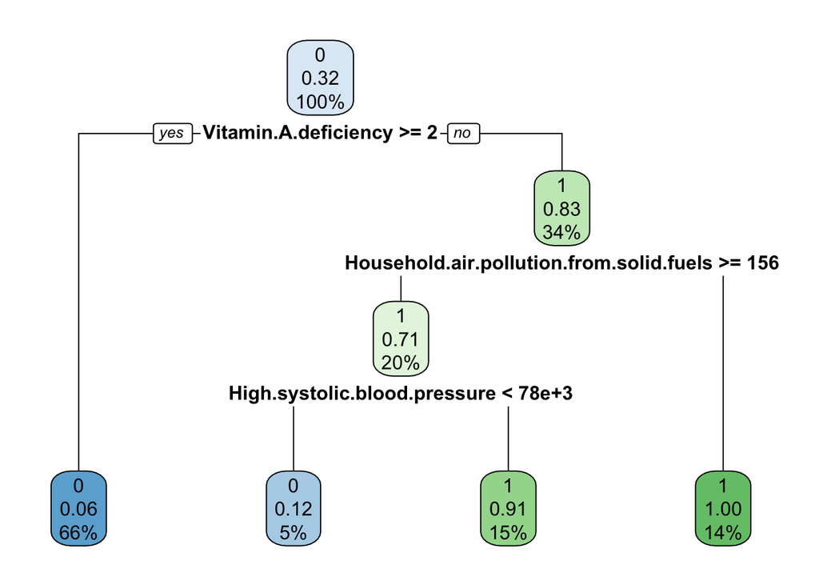

```r
library(rpart)
library(rpart.plot)
decision_full_model <- rpart(Label ~ ., data = train_data[, c(all_features, "Label")], method = "class",control = rpart.control(cp = 0.01))
rpart.plot(decision_full_model)
```

```r
#As we change the label of the previous part to 0, now we just change back to 1
calcAUC <- function(predcol,outcol) {
  perf <- performance(prediction(predcol,outcol==1),'auc')
  as.numeric(perf@y.values)
}
```

```r
print(calcAUC(predict(decision_full_model, train_data)[,2], train_data[,"Label"]))
```

```
## [1] 0.9281752
```

```r
print(calcAUC(predict(decision_full_model, test_data)[,2], test_data[,"Label"]))
```

```
## [1] 0.872134
```

With full features, the decision tree classifiers perform much better than the single-variate model, with training AUC value of 0.928 andb AUC testing value of 0.872

```r
pretty_perf_table(decision_full_model, train_data, test_data, all_features, "decision_tree")
```

```
##
##
## model                  precision   recall       f1   accuracy
## -------------------- ----------- -------- -------- ----------
## logistic, training        0.9545   0.8571   0.9032     0.9408
## logistic, test            0.8889   0.7619   0.8205     0.8542
```

The model also so really good results for percision, recall, f1 and accurarcy

### Selected variables

As mentioned, there are 15 good classifier that we can use to classify the countries in high or non-high income groups. Therefore, we will use them to make the decision tree model.

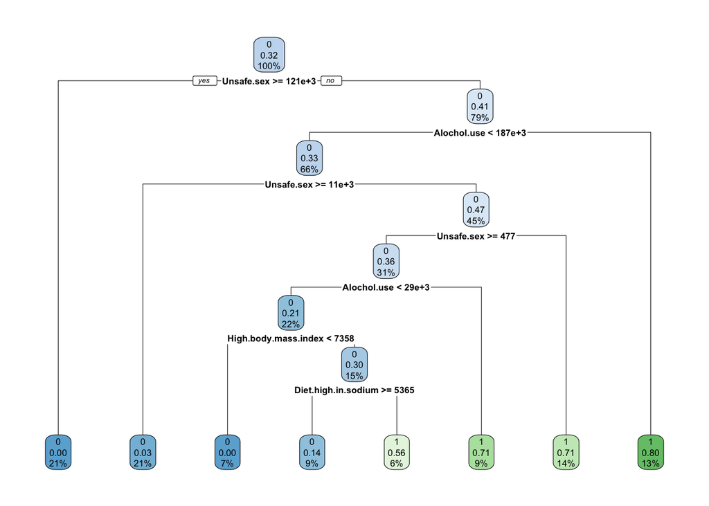

```r
decision_multi_var_model <- rpart(Label ~ ., data = train_data[, c(selected_features, "Label")], method = "class")
rpart.plot(decision_multi_var_model)
```

```r
print(calcAUC(predict(decision_multi_var_model, train_data)[,2], train_data[,"Label"]))
```

```
## [1] 0.9147018
```

```r
print(calcAUC(predict(decision_multi_var_model, test_data)[,2], test_data[,"Label"]))
```

```
## [1] 0.633157
```

With selected features, the decision tree classifiers perform closely to the full variables decision tree classifier better, around 0.01 different in AUC value. But with AUC testing value of 0.633, it is significantly lower thanfull variables decision tree classifier model’s AUC of around 0.24.

```r
pretty_perf_table(decision_multi_var_model, train_data, test_data, all_features, "decision_tree")
```

```
##
##
## model                  precision   recall       f1   accuracy
## -------------------- ----------- -------- -------- ----------
## logistic, training        0.7188   0.9388   0.8142     0.8618
## logistic, test            0.5926   0.7619   0.6667     0.6667
```

Based on the results of percision, recall, f1 and accurarcy, the selected variable decision tree classifier model did not performas good as the full variable model.

In short, based on AUC values, percision, recall, f1 and accurarcy calculated for 2 decision tree classifiers that we build, the model with all variables performs better than the 15-features-selected model.

## Logistic Regression

We will build the logistic regression classification model, with all the features ### Full model

```r
formula<-paste("Label", paste(all_features, collapse=" + "), sep=" ~ ")
log_full_model<-glm(formula=formula, data=train_data, family=binomial(link="logit"))
train_data$log_full_pred <- predict(log_full_model, newdata=train_data, type="response")
test_data$log_full_pred <- predict(log_full_model, newdata=test_data, type="response")
```

```r
pretty_perf_table(log_full_model, train_data, test_data, all_features, "logistic")
```

```
##
##
## model                  precision   recall       f1   accuracy
## -------------------- ----------- -------- -------- ----------
## logistic, training        0.5568   1.0000   0.7153     0.7434
## logistic, test            0.6129   0.9048   0.7308     0.7083
```

With the logistic regression for all variables, the percision value is only around 0.55 to 0.61 for precision, implies that the model is still around randomly guessing the values. F1 and accurarcy values are around 0.71 to 0.74 when training and testing, which are good. Recall value is really high, with maximum for training and 0.9 for testing

```r
library(knitr)
kable(table(truth=test_data$Label, prediction=test_data$log_full_pred>0.5))
```

|  | FALSE | TRUE |
| --- | --- | --- |
| 0 | 15 | 12 |
| 1 | 2 | 19 |

When we do the confusion matrix for the testing dataset, the model predict correctly 19 countries in high-income group, while only 2 wrong. However, the model did not well classify the countries from non-high income groups, there are 12 values predicted wrong to high-income country group. The investigation of the model will be demonstrate later.

### Selected feature

We will build the logistic regression classification model, with 15 selected features

```r
formula<-paste("Label", paste(selected_features, collapse=" + "), sep=" ~ ")
log_multi_var_model<-glm(formula=formula, data=train_data, family=binomial(link="logit"))
train_data$log_multi_var_pred <- predict(log_multi_var_model, newdata=train_data, type="response")
test_data$log_multi_var_pred <- predict(log_multi_var_model, newdata=test_data, type="response")
```

```r
pretty_perf_table(log_multi_var_model, train_data, test_data, all_features, "logistic")
```

```
##
##
## model                  precision   recall       f1   accuracy
## -------------------- ----------- -------- -------- ----------
## logistic, training        0.7963   0.8776   0.8350     0.8882
## logistic, test            0.7727   0.8095   0.7907     0.8125
```

Suprisingly, the logistic regression for 15-selected variables, the percision, f1 and accurarcy values are larger when comparing to the ones of full variable model in both training and testing, which are really good. However, recall value is smaller than full-feature classifier’s recall, but still it signify a good classification model.

```r
kable(table(truth=test_data$Label, prediction=test_data$log_multi_var_pred>0.5))
```

|  | FALSE | TRUE |
| --- | --- | --- |
| 0 | 22 | 5 |
| 1 | 4 | 17 |

When we do the confusion matrix for the testing dataset, the model predict correctly 17 countries in high-income group, while 4 wrong. However, the model did much better in classifying the countries from non-high income groups, there are 22 values predicted correctly and only 5 were incorrectly predicted to high-income country group. In overall, the selected-features logistic regression classification model performes better than the full variables one.

#### Additional ROC plots

With the ROC plots, we will compare how 2 models perform with the same set of features

We will start with 2 models with full features.

```r
#this is the code followed from the lecture, with some modification
library(ROCit)
# Function to plot ROC curves for both logistic regression and decision tree models
plot_roc <- function(predcol1_test, outcol1_test, predcol1_train, outcol1_train,
                     predcol2_test, outcol2_test, predcol2_train, outcol2_train) {
  #we calcualte the ROC for the first model, which is the logistic regression model
  roc_1_test <- rocit(score = predcol1_test, class = outcol1_test == 1)
  roc_1_train <- rocit(score = predcol1_train, class = outcol1_train == 1)
  #we calcualte the ROC for the first model, which is the decision tree model
  roc_2_test <- rocit(score = predcol2_test, class = outcol2_test == 1)
  roc_2_train <- rocit(score = predcol2_train, class = outcol2_train == 1)
  # Plot test data for both models
  plot(roc_1_test, col = c("blue", "green"), lwd = 2, legend = FALSE, YIndex = FALSE, values = TRUE, asp = 1)
  lines(roc_2_test$TPR ~ roc_2_test$FPR, col = c("red", "green"), lwd = 2)
  lines(roc_1_train$TPR ~ roc_1_train$FPR, col = c("blue", "green"), lwd = 2, lty = 2)
  lines(roc_2_train$TPR ~ roc_2_train$FPR, col = c("red","green"), lwd = 2, lty = 2)
  #we add the legend to classify the training and testing lines for each model
  legend("bottomright", col = c("blue", "red","green"),
         legend = c("Logistic Test", "Decision Tree Test", "Null Model", "Logistic Train", "Decision Tree Train"),
         lwd = 2,lty = c(1, 1, 2, 2, 2))
}
```

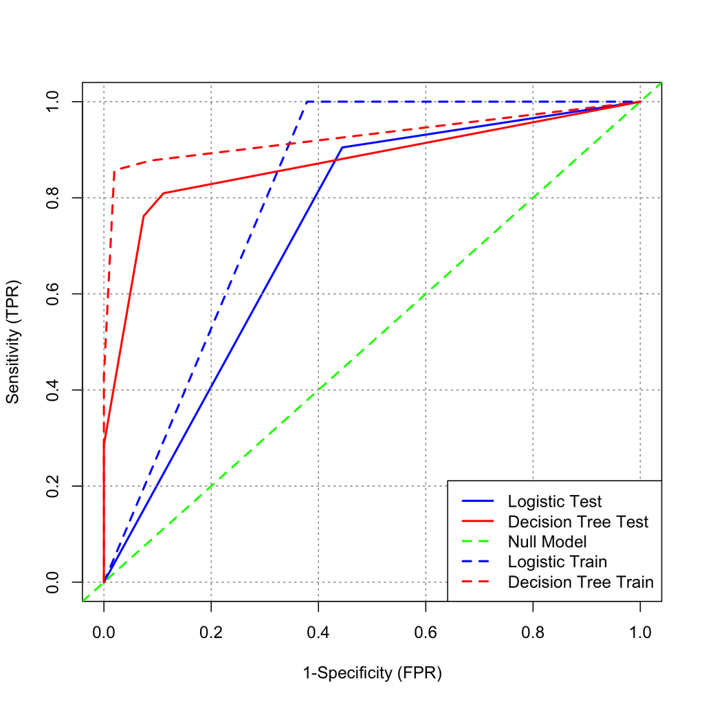

```r
#we generate predictions for both full-variables models on test and training datasets
#logistic regression model (using response)
pred_log_full_test <- predict(log_full_model, newdata = test_data, type = "response")
pred_log_full_train <- predict(log_full_model, newdata = train_data, type = "response")
#decision tree model (using probability)
pred_tree_full_test <- predict(decision_full_model, newdata = test_data, type = "prob")[, 2]
pred_tree_full_train <- predict(decision_full_model, newdata = train_data, type = "prob")[, 2]

plot_roc(pred_log_full_test, test_data$Label, pred_log_full_train, train_data$Label, pred_tree_full_test, test_data$Label, pred_tree_full_train, train_data$Label)
```

In the ROC plot for all features models, both the models perform better than the Null model. The decsion tree classifier’s training and testing lines are closer to top left corner, in comparision to logistic regression classifier. Therefore, decsion tree classifier with full variables are better classifier.

We will do the same thing with 2 models with selected features.

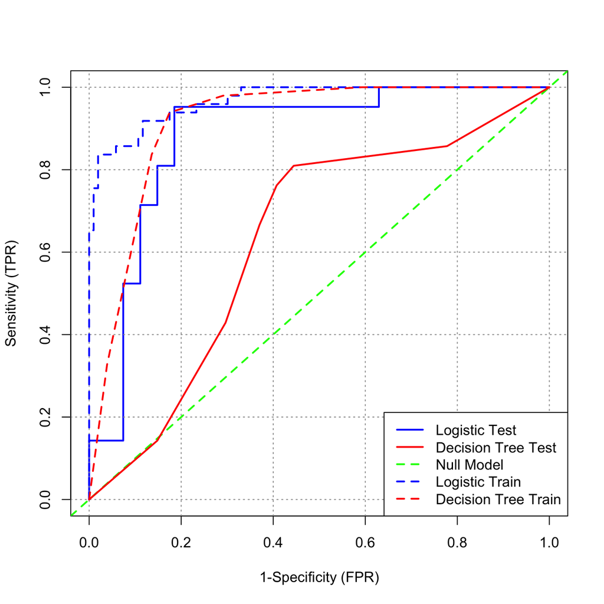

```r
#we generate predictions for both selected-features models on test and training datasets
#logistic regression model (using response)
pred_log_multi_test <- predict(log_multi_var_model, newdata = test_data, type = "response")
pred_log_multi_train <- predict(log_multi_var_model, newdata = train_data, type = "response")
#decision tree model (using probability)
pred_tree_multi_test <- predict(decision_multi_var_model, newdata = test_data, type = "prob")[, 2]
pred_tree_multi_train <- predict(decision_multi_var_model, newdata = train_data, type = "prob")[, 2]

plot_roc(pred_log_multi_test, test_data$Label, pred_log_multi_train, train_data$Label, pred_tree_multi_test, test_data$Label, pred_tree_multi_train, train_data$Label)
```

# Clustering

We will now working on clustering our data. For this one, the regions total death will be used. However, the column Income.group will not be included in this dataset, as it works as a label for the data. Therefore, the dataset will only include regions with total death records for each of the death cause.

First of all, we have to transform the data.

```r
head(regions)
```

```
##                  Entity Code Year Outdoor.air.pollution
## 31 African Region (WHO)      1990                 93970
## 32 African Region (WHO)      1991                 96436
## 33 African Region (WHO)      1992                 99700
## 34 African Region (WHO)      1993                101913
## 35 African Region (WHO)      1994                105532
## 36 African Region (WHO)      1995                109104
##    High.systolic.blood.pressure Diet.high.in.sodium Diet.low.in.whole.grains
## 31                       356866               46758                    45763
## 32                       365975               47439                    46897
## 33                       377948               48304                    48317
## 34                       386490               48805                    49393
## 35                       398794               49520                    50736
## 36                       410153               50425                    51970
##    Alochol.use Diet.low.in.fruits Unsafe.water.source Secondhand.smoke
```

[output cut: 48 more lines]

```r
total_regions_death <- regions %>% group_by(Entity) %>% summarise(across(c("Outdoor.air.pollution": "Iron.deficiency"), sum))
head(total_regions_death)
```

```
## # A tibble: 6 × 29
##   Entity        Outdoor.air.pollution High.systolic.blood.…¹ Diet.high.in.sodium
##   <fct>                         <int>                  <int>               <int>
## 1 African Regi…               4818693               15828295             1704129
## 2 East Asia & …              40472023               84424116            27166907
## 3 Eastern Medi…               8208846               18299605             1010466
## 4 Europe & Cen…              17080264               72954118             9030712
## 5 European Reg…              17240142               73420126             9121620
## 6 G20                        74123621              185294122            37385534
## # ℹ abbreviated name: ¹High.systolic.blood.pressure
## # ℹ 25 more variables: Diet.low.in.whole.grains <int>, Alochol.use <int>,
## #   Diet.low.in.fruits <int>, Unsafe.water.source <int>,
## #   Secondhand.smoke <int>, Low.birth.weight <int>, Child.wasting <int>,
## #   Unsafe.sex <int>, Diet.low.in.nuts.and.seeds <int>,
## #   Household.air.pollution.from.solid.fuels <int>,
## #   Diet.low.in.Vegetables <int>, Low.physical.activity <int>, Smoking <int>, …
```

```r
cluster_data<-total_regions_death
```

```r
head(cluster_data)
```

```
## # A tibble: 6 × 29
##   Entity        Outdoor.air.pollution High.systolic.blood.…¹ Diet.high.in.sodium
##   <fct>                         <int>                  <int>               <int>
## 1 African Regi…               4818693               15828295             1704129
## 2 East Asia & …              40472023               84424116            27166907
## 3 Eastern Medi…               8208846               18299605             1010466
## 4 Europe & Cen…              17080264               72954118             9030712
## 5 European Reg…              17240142               73420126             9121620
## 6 G20                        74123621              185294122            37385534
## # ℹ abbreviated name: ¹High.systolic.blood.pressure
## # ℹ 25 more variables: Diet.low.in.whole.grains <int>, Alochol.use <int>,
## #   Diet.low.in.fruits <int>, Unsafe.water.source <int>,
## #   Secondhand.smoke <int>, Low.birth.weight <int>, Child.wasting <int>,
## #   Unsafe.sex <int>, Diet.low.in.nuts.and.seeds <int>,
## #   Household.air.pollution.from.solid.fuels <int>,
## #   Diet.low.in.Vegetables <int>, Low.physical.activity <int>, Smoking <int>, …
```

We need to scale the data, with mean of 0 and standard deviation of 1

```r
scale_data<-scale(cluster_data[, 2:ncol(cluster_data)]) # this will be the data where each column has 0 mean and unit standard deviation
```

```r
attr(scale_data, "scaled:scale")
```

```
##                    Outdoor.air.pollution
##                               25520119.4
##             High.systolic.blood.pressure
##                               62374453.2
##                      Diet.high.in.sodium
##                               13493389.0
##                 Diet.low.in.whole.grains
##                               10686499.1
##                              Alochol.use
##                               15372499.4
##                       Diet.low.in.fruits
##                                6981718.7
##                      Unsafe.water.source
##                               15971470.2
##                         Secondhand.smoke
##                                9159291.2
##                         Low.birth.weight
##                               19277832.1
##                            Child.wasting
##                               16615990.6
##                               Unsafe.sex
##                                9764493.0
##               Diet.low.in.nuts.and.seeds
##                                3790451.3
## Household.air.pollution.from.solid.fuels
##                               26326441.5
##                   Diet.low.in.Vegetables
##                                3269839.5
##                    Low.physical.activity
##                                4454873.8
##                                  Smoking
##                               53103237.1
##              High.fasting.plasma.glucose
##                               31608499.4
##                            Air.pollution
##                               48914564.7
##                     High.body.mass.index
##                               24287554.7
##                        Unsafe.sanitation
##                               11447886.6
##        No.access.to.handwashing.facility
##                                7633679.3
##                                 Drug.use
##                                2829930.2
##                 Low.bone.mineral.density
##                                2284732.7
##                     Vitamin.A.deficiency
##                                 914030.2
##                           Child.stunting
##                                3883561.2
##               Discontinued.breastfeeding
##                                 139979.8
##              Non.exclusive.breastfeeding
##                                2378032.7
##                          Iron.deficiency
##                                 490187.5
```

```r
attr(scale_data, "scaled:center")
```

```
##                    Outdoor.air.pollution
##                               23985405.6
##             High.systolic.blood.pressure
##                               63641609.4
##                      Diet.high.in.sodium
##                               11510138.1
##                 Diet.low.in.whole.grains
##                               10976485.2
##                              Alochol.use
##                               15605602.9
##                       Diet.low.in.fruits
##                                6788996.5
##                      Unsafe.water.source
##                               12322135.6
##                         Secondhand.smoke
##                                8603054.3
##                         Low.birth.weight
##                               16519883.2
##                            Child.wasting
##                               13879288.2
##                               Unsafe.sex
##                                7698579.7
##               Diet.low.in.nuts.and.seeds
##                                3671486.5
## Household.air.pollution.from.solid.fuels
##                               23462395.1
##                   Diet.low.in.Vegetables
##                                3384547.8
##                    Low.physical.activity
##                                4689670.7
##                                  Smoking
##                               51786768.8
##              High.fasting.plasma.glucose
##                               33390368.5
##                            Air.pollution
##                               46462239.1
##                     High.body.mass.index
##                               25539739.7
##                        Unsafe.sanitation
##                                8808695.3
##        No.access.to.handwashing.facility
##                                6073371.3
##                                 Drug.use
##                                2928390.8
##                 Low.bone.mineral.density
##                                2331194.2
##                     Vitamin.A.deficiency
##                                 684348.4
##                           Child.stunting
##                                3101030.9
##               Discontinued.breastfeeding
##                                 119825.6
##              Non.exclusive.breastfeeding
##                                1992203.0
##                          Iron.deficiency
##                                 396643.2
```

We will calculate the distance using euclidean distance, to form the vectors (or lines) of seperation between groups.

```r
d<-dist(scale_data, method="euclidean")
d
```

```
##              1           2           3           4           5           6
## 2   6.37544569
## 3   4.59929867  4.60126966
## 4   6.45017890  3.24962371  3.32661159
## 5   6.46063715  3.24158942  3.34637298  0.02606892
## 6  10.99461960  7.50416240 11.28697488  9.28062174  9.26117459
## 7   5.32504561  4.77513092  1.16249489  3.18674910  3.20875741 11.69252253
## 8   5.52229383  5.04148258  1.19661378  3.39499484  3.41703603 11.98133271
## 9   5.77596558  4.87332875  1.62804684  3.17821403  3.20027367 11.83298888
## 10  6.24067618  3.28984600  3.00108668  1.14788768  1.15394595  9.57714287
## 11  5.40276662  4.02636345  1.57692756  2.33104285  2.35059391 10.78329478
## 12  3.79073626  4.39435560  4.05943932  4.94714271  4.95251676  8.75372441
## 13  4.00385364  3.97300346  4.15225924  4.73729039  4.74105235  8.35308558
## 14  0.30197378  6.55584908  4.85170412  6.68581925  6.69586074 11.01999387
## 15  6.25687952  1.03947727  3.86674274  2.65465116  2.65177941  8.44357014
## 16 16.78643330 15.82068881 18.88760225 17.61320779 17.59682938  9.18107385
## 17  6.25046883  3.37485206  2.91333685  1.21508273  1.22458784  9.74260526
## 18  2.37165958  5.34558203  2.42398148  4.87566103  4.89161471 11.30225435
## 19  5.57922824  6.83707987  7.89713088  8.11844852  8.11482322  7.23373393
## 20  7.23015067  1.88276209  5.76188434  3.52302676  3.50528169  6.34610983
##              7           8           9          10          11          12
## 2
## 3
## 4
## 5
## 6
## 7
## 8   0.58194886
## 9   0.75973901  0.77003187
## 10  2.74691438  3.00603896  2.64975484
## 11  1.13213742  1.48820647  1.17948855  1.71091722
## 12  4.92351047  5.10656646  5.28148085  4.91348240  4.64744290
## 13  4.93013829  5.14436370  5.25705322  4.69362610  4.56205309  0.63078190
## 14  5.59520607  5.78910885  6.04552927  6.48362280  5.66703046  3.89501095
## 15  3.92227167  4.16076843  3.98082550  2.63439452  3.22955092  4.49011536
## 16 19.54005154 19.83418423 19.81225686 17.88189296 18.76623935 15.54767628
## 17  2.61292133  2.86404011  2.48302225  0.21543312  1.59239534  4.95528584
## 18  3.13692231  3.28688764  3.58491790  4.59266361  3.42881020  3.46439985
## 19  8.76875745  8.99931919  9.15277973  8.21976114  8.33672789  4.15785606
## 20  5.89615201  6.17581933  5.99226130  3.85231350  5.01215078  5.32297331
```

[output cut: 25 more lines]

```
## 6
## 7
## 8
## 9
## 10
## 11
## 12
## 13
## 14
## 15
## 16
## 17
## 18
## 19
## 20  7.02261243
```

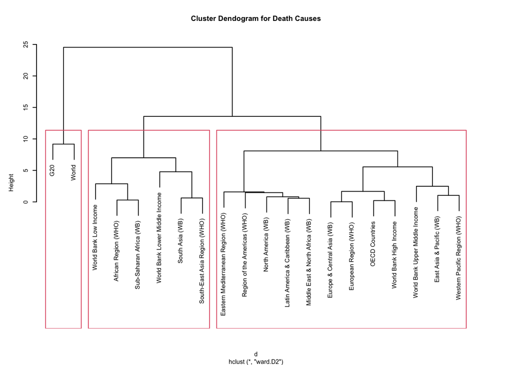

```r
pfit<-hclust(d,method="ward.D2")
par(cex=0.5, mar=c(5, 5, 5, 5)) #we adjust the size of dendogram to be bigger and the labels be smaller
plot(pfit, labels = cluster_data$Entity, main="Cluster Dendogram for Death Causes") #we perform a hierarchial clustering
rect.hclust(pfit, k=3) #we will divide into 3 groups
```

With the optimal k is 3, all the data points were divided into 3 groups: - World and G20 - Low-income, African, South and South-East Asian countries - High income countries and other regions which seems to be developed countries.

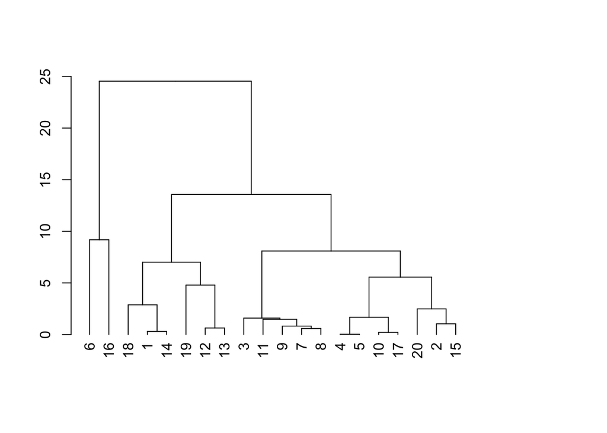

```r
plot(as.dendrogram(pfit), xlim=c(1, 25))
```

This is the cutree function, which returns a vector of clustering group assigned to each row.

```r
groups <- cutree(pfit, k=3)
groups
```

```
##  [1] 1 2 2 2 2 3 2 2 2 2 2 1 1 1 2 3 2 1 1 2
```

Now we will visualise the clusters. To do that, we will perform principle components - dimension reduction, to visualise the cluster groups on 2 principal components (or 2D graph).

```r
princ <- prcomp(scale_data) #we calculate the principal components of scaled_df
nComp <- 2
project2D <- as.data.frame(predict(princ, newdata=scale_data)[,1:nComp]) #we put the scale data on the principal components dataframe
hclust.project2D <- cbind(project2D, cluster=as.factor(groups), country=cluster_data$Entity)
head(hclust.project2D)
```

```
##             PC1           PC2 cluster                            country
## 1 -1.539685e-06 -2.793017e-06       1               African Region (WHO)
## 2  8.217947e-07  1.294741e-06       2           East Asia & Pacific (WB)
## 3  8.461998e-07  4.718111e-07       2 Eastern Mediterranean Region (WHO)
## 4  1.608854e-06  2.126974e-06       2         Europe & Central Asia (WB)
## 5  1.606165e-06  2.127579e-06       2              European Region (WHO)
## 6 -1.700115e-06 -4.517925e-07       3                                G20
```

```r
#this is the code from the lecture, with modification
#finding convex hull
library('grDevices')
#this function will return the vector of points in each convex hull
find_convex_hull <- function(proj2Ddf, groups) {
  do.call(rbind,lapply(unique(groups), FUN = function(c) {
    f <- subset(proj2Ddf, cluster==c);
    f[chull(f),] # this compute the convex hull of a set of points
    }))
  }
hclust.hull <- find_convex_hull(hclust.project2D, groups)
```

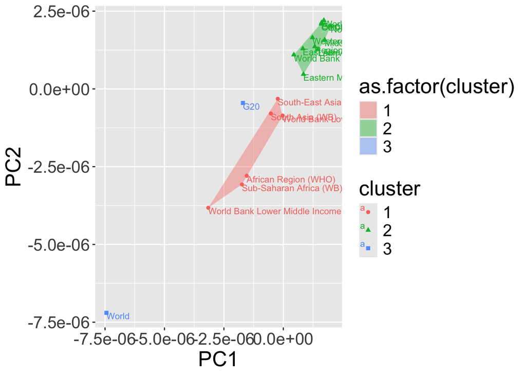

```r
#this is the code from lecture
ggplot(hclust.project2D, aes(x=PC1, y=PC2)) + geom_point(aes(shape=cluster, color=cluster)) + geom_text(aes(label=country, color=cluster), hjust=0, vjust=1, size=3) + geom_polygon(data=hclust.hull, aes(group=cluster, fill=as.factor(cluster)),alpha=0.4, linetype=0) + theme(text=element_text(size=20))
```

We can see that the data are divided into 3 groups, similar to the dendogram that we have above.

We do not know which is the optimal number of k to divide the data into k groups. Therefore, we will find the number of cluster k.

There are 2 ways to find optimal k, either by looking for elbow curve when we calculate all k within sum of squares(WSS) or by calculating the Calinski-Harabasz index. In this paper work, the method of calculating WSS will be applied.

```r
#these are the code followed from the lecture, with some modification.
#this function will return the squared Euclidean distance of two given points x and y from the cluster centroid
sqr_euDist <- function(x, y) {
  sum((x - y)^2)
}
#this function calculates WSS of a cluster, represented as a n-by-d matrix (n is number of rows and d is the number of column) which contains only points of the cluster.
wss <- function(clustermat) {
  c0 <- colMeans(clustermat)
  sum(apply( clustermat, 1, FUN=function(row) {sqr_euDist(row, c0)} ))
}
#this function will calculate the total WSS.
wss_total <- function(scaled_df, labels) {
  wss.sum <- 0
  k <- length(unique(labels))
  for (i in 1:k)
    wss.sum <- wss.sum + wss(subset(scaled_df, labels == i))
    wss.sum
}
#this function will calculate the total sum of squared (TSS) distance of data points about the mean. This is the same as WSS when the k equals to 1.
tss <- function(scaled_df) {
  wss(scaled_df)
}
```

```r
#this is the code followed from the lecture, with modification
#this function will return the  indices computed using k-means clustering (`kmeans`) for a vector of k values ranging from 1 to kmax.
calculate_indices <- function(scaled_df, kmax) {
  npts <- nrow(scaled_df)
  wss.value <- numeric(kmax) # create a vector of numeric type
  # wss.value[1] stores the WSS value for k=1 (when all the
  # data points form 1 large cluster).
  wss.value[1] <- wss(scaled_df)
  d <- dist(scaled_df, method="euclidean")
  pfit <- hclust(d, method="ward.D2")
  for (k in 2:kmax) {
    labels <- cutree(pfit, k=k)
    wss.value[k] <- wss_total(scaled_df, labels)
  }
  bss.value <- tss(scaled_df) - wss.value # this is a vector
  B <- bss.value / (0:(kmax-1)) # also a vector
  W <- wss.value / (npts - 1:kmax) # also a vector
  data.frame(k = 1:kmax, CH_index = B/W, WSS = wss.value)
}
```

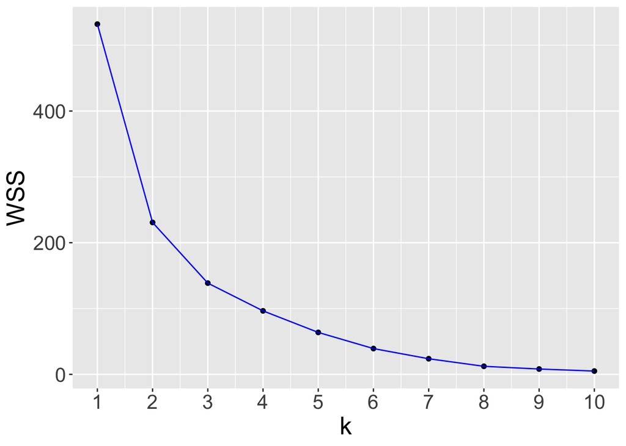

```r
library(gridExtra)
# calculate the CH criterion
crit.df <- calculate_indices(scale_data, 10)
ggplot(crit.df, aes(x=k, y=WSS), color="blue") + geom_point() + geom_line(colour="blue") + scale_x_continuous(breaks=1:10, labels=1:10) + theme(text=element_text(size=20))
```

## Shiny App

For every graphs coverd in this report, it will all be put in this Shiny app. This Shiny app includes: - Exploratory Data Analysis - Decision Tree Classification Modelling - Logistic Regression Classification Modelling - ROC plots to evaluate AUC - Clustering

```r
logistic_model <- NULL
decision_model <- NULL
# Define UI for application that draws different plot
ui <- navbarPage(
    "Analysis of number of recorded deaths and causes in countries/regions during 1990 - 2019",
  #Tab1: EDA
    tabPanel("EDA",
    sidebarLayout(
        sidebarPanel(
          selectInput("plot_type", "Select plot type:", choices = c("Line plot", "Boxplot", "Heat map", "Correlation plot")),
            conditionalPanel(
              condition = "input.plot_type == 'Line plot'",
              checkboxInput("compare", "Compare between 2 countries/regions", FALSE),
            ),
            selectInput("region1", "Choose the first country/region:", choices = unique(data$Entity)),
            conditionalPanel(
              condition = "input.compare == true",
              selectInput("region2", "Choose the second country/region:", choices = unique(data$Entity))
            ),
            conditionalPanel(
              condition = "input.plot_type == 'Line plot'",
              selectInput("reason", "Choose death reason:", choices = names(data)[4:31])
            ),
        ),
        mainPanel(
          plotOutput("plot1", width = "100%", height = "600px"),
            conditionalPanel(
                condition = "input.compare == true && input.plot_type == 'Line plot'",  # Display plot2 only if compare is checked
                plotOutput("plot2", width = "100%", height = "600px"))
        )
    )
),
#Tab2: Decision Tree Classification Model
  tabPanel("Decision Tree Classification Model",
    sidebarLayout(
      sidebarPanel(
        radioButtons("tree_variable_set", "Select variable set:", choices = c("all_features", "selected_features"))
      ),
      mainPanel(
        plotOutput("decision_tree", width = "100%", height = "400px"),
        tableOutput("decision_tree_perf_table")

      )
    )
  ),
#Tab3: Logistic Regression Model
  tabPanel("Logistic Regression Classification Model",
    sidebarLayout(
      sidebarPanel(
        radioButtons("logistic_variable_set", "Select variable set:", choices = c("all_features", "selected_features"))
      ),
      mainPanel(
        tableOutput("logistic_perf_table")

      )
    )
  ),
#Tab4: Plot ROC
  tabPanel("Plots to compare AUC",
    sidebarLayout(
      sidebarPanel(
        radioButtons("variable_set", "Select variable set:", choices = c("all_features", "selected_features"))
      ),
      mainPanel(
        plotOutput("ROC_plot", width = "100%", height = "400px"),
      )
    )
  ),
#Tab5: Clustering
  tabPanel("Clustering",
    sidebarLayout(
      sidebarPanel(
          selectInput("clustering_plot_type", "Select plot type:", choices = c("Dendogram", "Cluster Visualisation","WSS plot"))
      ),
      mainPanel(
        plotOutput("clustering_plot", width = "100%", height = "400px"),
      )
),
),
)


# Define the server
server <- function(input, output){
    # Render the histograms
    output$plot1 <- renderPlot({
      region_data<-data[data$Entity==input$region1,]
      # Plot selected death reason
      if (input$plot_type == 'Line plot'){
      ggplot(region_data, aes_string(x="Year", y=input$reason, group = "Entity")) +
          geom_line(color="darkorange") +
          labs(x="Year", y = input$reason) +
          theme(axis.text.x = element_text(angle = 45, hjust = 1))}
      # Plot the boxplot
      else if (input$plot_type == 'Boxplot'){
        data_melt <- melt(region_data, id.vars = "Year", measure.vars = names(data)[4:31],
                          variable.name = "death_reason", value.name = "value")
        ggplot(data_melt, aes(x = death_reason, y = value, fill = death_reason)) +
          geom_boxplot() +
          labs(x = "Death Reason", y = "Number of Deaths", title = paste("Boxplot of Death Reasons in", input$region1)) +
          theme_minimal() +
          theme(axis.text.x = element_text(angle = 45, hjust = 1), legend.position = "top")+
          guides(fill = guide_legend(ncol = 3))
        }

      # Plot the Heat Map for selected country
      else if (input$plot_type == 'Heat map'){
        data_melt <- melt(region_data, id.vars = "Year", measure.vars = names(data)[4:31], variable.name = "death_reason", value.name = "value")
        # Create heat map
        ggplot(data_melt, aes(x = Year, y = death_reason, fill = value)) +
            geom_tile() +
            scale_fill_gradient(low = "aliceblue", high = "blue") +
            scale_x_discrete(breaks = levels(region_data$Year)) +
            labs(x = "Year", y = "Death Reason", title = paste("Heat Map of Death Reasons in", input$region1)) +
            theme_minimal() +
            theme(axis.text.x = element_text(angle = 45, hjust = 1))
      }
      else if (input$plot_type == "Correlation plot"){
        # Extract the number of death for each death reasons
        numeric_data <- region_data[,4:31]

        # Calculate the correlation for all variables
        correlation <- cor(numeric_data)

        # Melt the correlation for visualization
        correlation_melted <- melt(correlation)

        # Create the correlation heatmap
        ggplot(correlation_melted, aes(x = Var1, y = Var2, fill = value)) +
          geom_tile() +
          scale_fill_gradient2(low = "blue", mid = "white", high = "red", midpoint = 0, limit = c(-1, 1), name = "Correlation") +
          theme_minimal() +
          theme(axis.text.x = element_text(angle = 45, hjust = 1)) +
          labs(title = "Correlation Plot of Death Reasons", x = "Variables", y = "Variables")
      }
    })
    output$plot2 <- renderPlot({
      if (input$compare == TRUE && input$plot_type == 'Line plot'){
      region_data<-data[data$Entity==input$region2,]
      # Plot all death reasons
      ggplot(region_data, aes_string(x="Year", y=input$reason, group ="Entity")) + geom_line(color="darkolivegreen") + labs(x="Year", y = input$reason)
    }
  })
  # Decision Tree classification model
  output$decision_tree <- renderPlot({
    variable_set <- input$tree_variable_set
    if (variable_set == "all_features") {
      decision_model <- rpart(Label ~ ., data = train_data[, c(all_features, "Label")], method = "class",control = rpart.control(cp = 0.01))
    } else {
      decision_model <- rpart(Label ~ ., data = train_data[, c(selected_features, "Label")], method = "class")
    }
    rpart.plot(decision_model)
  })
  output$decision_tree_perf_table <- renderTable({
  # Get predictions from the decision tree model
    variable_set <- input$tree_variable_set
    if (variable_set == "all_features") {
      decision_model <- rpart(Label ~ ., data = train_data[, c(all_features, "Label")], method = "class",control = rpart.control(cp = 0.01))
    } else {
      decision_model <- rpart(Label ~ ., data = train_data[, c(selected_features, "Label")], method = "class")
    }
    table<-pretty_perf_table(decision_model, train_data, test_data, all_features, "decision_tree")
    table
})
  #
  output$logistic_perf_table <- renderTable({
  # Get predictions from the logistic regression model
    variable_set <- input$logistic_variable_set
    if (variable_set == "all_features") {
      formula<-paste("Label", paste(all_features, collapse=" + "), sep=" ~ ")
      logistic_model<-glm(formula=formula, data=train_data, family=binomial(link="logit"))
    } else {
      formula<-paste("Label", paste(selected_features, collapse=" + "), sep=" ~ ")
      logistic_model <- glm(formula=formula, data=train_data, family=binomial(link="logit"))
    }
    table<-pretty_perf_table(logistic_model, train_data, test_data, all_features, "logistic")
    table
})
  #ROC plot
  output$ROC_plot <- renderPlot({
  # Get predictions from the logistic regression model
    variable_set <- input$variable_set
    if (variable_set == "all_features") {
      formula<-paste("Label", paste(all_features, collapse=" + "), sep=" ~ ")
      logistic_model<-glm(formula=formula, data=train_data, family=binomial(link="logit"))
      pred_log_test <- predict(logistic_model, newdata = test_data, type = "response")
      pred_log_train <- predict(logistic_model, newdata = train_data, type = "response")
      #decision tree model (using probability)
      decision_model <- rpart(Label ~ ., data = train_data[, c(all_features, "Label")], method = "class",control = rpart.control(cp = 0.01))
      pred_tree_test <- predict(decision_model, newdata = test_data, type = "prob")[, 2]
      pred_tree_train <- predict(decision_model, newdata = train_data, type = "prob")[, 2]

      plot_roc(pred_log_test, test_data$Label, pred_log_train, train_data$Label, pred_tree_test, test_data$Label, pred_tree_train, train_data$Label)
    } else {
      formula<-paste("Label", paste(selected_features, collapse=" + "), sep=" ~ ")
      logistic_model<-glm(formula=formula, data=train_data, family=binomial(link="logit"))
      pred_log_test <- predict(logistic_model, newdata = test_data, type = "response")
      pred_log_train <- predict(logistic_model, newdata = train_data, type = "response")
      #decision tree model (using probability)
      decision_model <- rpart(Label ~ ., data = train_data[, c(selected_features, "Label")], method = "class",control = rpart.control(cp = 0.01))
      pred_tree_test <- predict(decision_model, newdata = test_data, type = "prob")[, 2]
      pred_tree_train <- predict(decision_model, newdata = train_data, type = "prob")[, 2]

      plot_roc(pred_log_test, test_data$Label, pred_log_train, train_data$Label, pred_tree_test, test_data$Label, pred_tree_train, train_data$Label)
    }
})
  #Clustering
  output$clustering_plot <- renderPlot({
    clustering_plot_type <- input$clustering_plot_type
    d<-dist(scale_data, method="euclidean")
    scale_data<-scale(cluster_data[, 2:ncol(cluster_data)])
    pfit<-hclust(d,method="ward.D2")
    if (clustering_plot_type == "Dendogram") {
      par(cex=0.5, mar=c(5, 5, 5, 5)) #we adjust the size of dendogram to be bigger and the labels be smaller
      plot(pfit, labels = cluster_data$Entity, main="Cluster Dendogram for Death Causes") #we perform a hierarchial clustering
      rect.hclust(pfit, k=3) #we will divide into 3 groups
    } else if (clustering_plot_type == "Cluster Visualisation") {
      groups <- cutree(pfit, k=3)

      princ <- prcomp(scale_data) #we calculate the principal components of scaled_df
      nComp <- 2
      project2D <- as.data.frame(predict(princ, newdata=scale_data)[,1:nComp]) #we put the scale data on the principal components dataframe
      hclust.project2D <- cbind(project2D, cluster=as.factor(groups), country=cluster_data$Entity)

      hclust.hull <- find_convex_hull(hclust.project2D, groups)

      ggplot(hclust.project2D, aes(x=PC1, y=PC2)) + geom_point(aes(shape=cluster, color=cluster)) + geom_text(aes(label=country, color=cluster), hjust=0, vjust=1, size=3) + geom_polygon(data=hclust.hull, aes(group=cluster, fill=as.factor(cluster)),alpha=0.4, linetype=0) + theme(text=element_text(size=20))
    } else{ #WSS plot
      crit.df <- calculate_indices(scale_data, 10)
      ggplot(crit.df, aes(x=k, y=WSS), color="blue") + geom_point() + geom_line(colour="blue") + scale_x_continuous(breaks=1:10, labels=1:10) +     theme(text=element_text(size=20))
    }
  })
}

# Run the Shiny app
shinyApp(ui = ui, server = server)
```

Shiny applications not supported in static R Markdown documents

# Conclusion

To sum up everything, we have done the analysis of Countries’ numbers of death and causes during 1990-2019 with the dataset provided by World Bank.

With the exploratary data analysis, we found out that the dataset includes numbers of death not only in different countries, but also in different groups, regions and the World, which makes the death causes got the numbers recorded vary in large range. Therefore we need to separate the dataset in to countries and regions.

With the clustering, the regions dataset was selected for this task. With the optimal k is 3, all the data points were divided into 3 groups: the first group of World and G20, the second group of countries with low-income, African countries, South and South-East Asia, and the third group of high income countries and other regions.

There are some improvement needed for this project. The main one is how to improve the model to predict better with higher chance of classifying correctly. Along with that, as the data are vary in a large range, the log-transformation could be performed to evaluate the models performance.